# Alcoholics Data Analysis

Trisha, Lapi, Vaibava

11/14/2022

# The Roots of the Problem: Alcoholism and How it Develops

**Code Name:** Roads-8

**Authors:** Trisha Vidyanand (trishav@uw.edu), Vaibava Venkatesan (vaibav@uw.edu), Lapi Kerr (lapikerr@uw.edu)

**Affiliation:** INFO-201: Technical Foundations of Informatics - The Information School - University of Washington

**Date:** Autumn 2022

### *Abstract*

The main question that we are addressing through our project is when alcohol consumption becomes an issue and what the side effects to it are. This question is important because most people turn towards alcohol to have a “good” time, making alcoholism a huge problem in society today. To address the question, we plan to look at and analyze data from reliable sources.

### *Keywords*

- alcoholism
- life expectancy
- happiness

### *Introduction*

Our project is focused on understanding who are most susceptible to becoming an alcoholic and comprehending the risks that come with becoming an alcoholic. We plan to analyze data from multiple reliable sources to try and answer our four main research questions. As more people turn towards alcohol to relieve their stress, this problem becomes more and more prevalent in society. Through our research for the project, we hope to show the risk factors (some temporary and some that last years) that come along with unhealthy amounts of alcohol consumption and why to avoid it. Through the data that we analyze we hope to help better human health.

### *Problem Domain*

Our problem domain is centered around the idea of alcoholism within society, particularly how it affects a broader network of people’s work and social interactions. We also hope to identify major risk factors that could contribute to drinking by drawing upon our various data sets in an attempt to understand where, why, and how individuals start drinking.

### *Human Values*

Our problem domain is concerned with the current population of adults, those who gradually transition into greater responsibilities with less and less support in an ever-changing world. More adults are falling prey to the allure of alcohol as an escape from these stresses; we value the health of everyone affected by alcoholism, mental and physical, above anything else. We have, at the core of our project, love and acceptance for those people who feel the temptation to start drinking, and hope to understand the factors and variables guiding the slippery slope so as to understand better prevention and avoidance tactics.

### *Stakeholders*

The main stakeholders of the project are humans under the intense stress of life, those looking for an escape. Regardless of if they have experienced the pressures of alcoholism or not, this project hopes to convey the negative effects of alcohol (through the prevalence of data explaining its risk factors and harmful effects) and the importance of avoiding it. The indirect stakeholders of this project are friends, parents, researchers, anyone who hopes to understand the potential risk factors behind developing alcoholism and form preventative measures against these factors.

### *Benefits and Harms*

The overall benefit of this project will be, with a combination of understanding the data and acting upon it, the betterment of human health across the world. A project such as this allows for harm just as much as benefit, however; harmful effects of this project develop when potential misinterpretation or misunderstanding of data leads researchers to focus on an entirely incorrect path of preventative measures. There is a responsibility on our shoulders to convey the data we have gathered in a way that can be understood by anyone who wishes to analyze it, and a responsibility to make sure our data comes from verifiable and reliable sources.

### *Research Questions*

**When does alcohol consumption become a problem?**

While being a fairly broad question, understanding the point where drinking goes from a fun hobby to a social and medical problem is vital for understanding the problems of alcoholism as a whole.

**What are some genetic predispositions or risk factors to alcoholism?**

Being able to understand risk factors and genetic predispositions to alcoholism will enable anyone to more broadly see the slippery slope of alcoholism and potential uncontrollable aspects of human biology (and psychology) that can lead to alcoholism.

**Which age range is the most broadly affected by alcoholism?**

This is a question that helps to give us an understanding of where alcoholism starts and tapers off (if at all). If we understand where it starts and where it ends, we can link that to other relevant ideas to determine the reasons that it starts and ends.

**What ethnic or racial backgrounds are most harshly affected by alcoholism?**

This is an uncomfortable question for some, but understanding that certain marginalized populations of ethnic and racial origin are unjustly affected by alcoholism when compared to others allows us to question further on the link between alcohol use/abuse and racial/ethnic lines (and especially question why it is there, if at all).

### *The Datasets*

Our datasets are related to our current problem domain because we focus on 3 aspects of alcohol consumption: Happiness, Life Expectancy, and prevalence throughout the world. The happiness dataset compiles data that determines which people experience momentary happiness while drinking alcohol. We also refer to datasets that determine the average life expectancy of an alcoholic, and how these patterns vary from country to country. We will be able to visualize more complex ideas of where alcohol addiction originates. For example, learning about the happiness index, and the part it plays in one’s psychological mind will help us form conclusions or inferences on whether people will look towards alcohol. Consequently, we will be able to confront our research questions because these factors play a major role within why people begin to consume alcohol.

| Name | Number of Observations | Number of Variables |
| --- | --- | --- |
| Happiness and Alcohol Consumption | 122 | 10 |
| Alcohol vs Life Expectancy | 193 | 17 |
| Student Alcohol Consumption | 395 | 89 |
| Binge Drinking within the World | 659 | 66 |

### *Our Datasets*

- [Happiness and Alcohol Consumption](https://www.kaggle.com/datasets/marcospessotto/happiness-and-alcohol-consumption)
- [Compendium - Alcohol Consumption](https://digital.nhs.uk/data-and-information/publications/statistical/compendium-public-health/current/alcohol-consumption)
- [Alcohol vs Life Expectancy](https://data.world/databeats/alcohol-vs-life-expectancy/workspace/file?filename=Drinks_raw.csv)
- [Student Alcohol consumption](https://data.world/data-society/student-alcohol-consumption)

These datasets tackle the primary question of why people consume alcohol. They were obtained from 3 main sources: Kaggle, NHS Digital, and Data World. These are all credible sources that millions of people use throughout the world. The data goes through many firewall transactions per day, and it is sharply monitored by cyber security and data analysts. All 3 of the sources utilize Google Analytics to collect their data for their data sets. Users also collect data from other sources to create specific data sets and produce a proper visualization for their projects. Specifically, NHS Digital collects data from their partnerships with hospital care records, systems, and other forms of organization. Most of the collected data did not require any form of money since most of the collected data is the result of partnerships with organizations. Instead, most data analysts benefit from the data, since they are able to create visualizations and edits of the data.

### *Expected Implications*

Assuming we answer our research questions:

**Question 1** would allow for policymakers to more directly limit consumption and purchasing of alcohol, still allowing for social/cultural/religious use but understanding where to draw the line at local levels (stores, bars, etc). Technologists would (hopefully) gain concrete reasoning to limit potential advertising, while designers and researchers would understand where to implement systems and limitations that may otherwise not exist or be overlooked in the current era.

**Question 2** wouldn’t really allow policymakers to do much without directly infringing upon personal privacy and rights, maybe other than offering care to specific groups of people, but technologists, researchers, and designers would all gain valuable insight into potentially linking factors that offer a place to start treatment/care and avoid advertising/selling.

**Question 3** gives all indirect stakeholders a concrete (or much less broad) place to start with treatment and care, as well as limitation and a good stepping stone for further research.

**Question 4** specifically allows policymakers to target alcohol companies who prey on harshly affected ethnic/racial backgrounds, as well as allowing all other indirect stakeholders a specific demographic to more specifically focus care and outreach on.

### *Limitations*

The largest limitation we have is personal privacy. Nobody wants to admit they have a problem, which is entirely understandable, but that leaves us unable to collect data from reliable personal sources. Our data should mainly come from doctor’s reports and rehabilitation efforts, both of which only come into play (usually) in the most dire of alcoholism related circumstances. We hope to address this by finding as many reliable datasets as possible and narrowing down the results to a set that are equally as reliable as they are relevant to our questions. As well as this, we have the ultimate limitation of circumstantial understanding; we can’t perfectly judge every aspect of the complex issue that is alcoholism around the world whether those be personal, cultural, social, or any other potential factors in play. We hope to reconcile this by using the Envisioning Cards and looking into the broad world of alcohol and how its existence plays into pre-existing problems.

## Chart 1

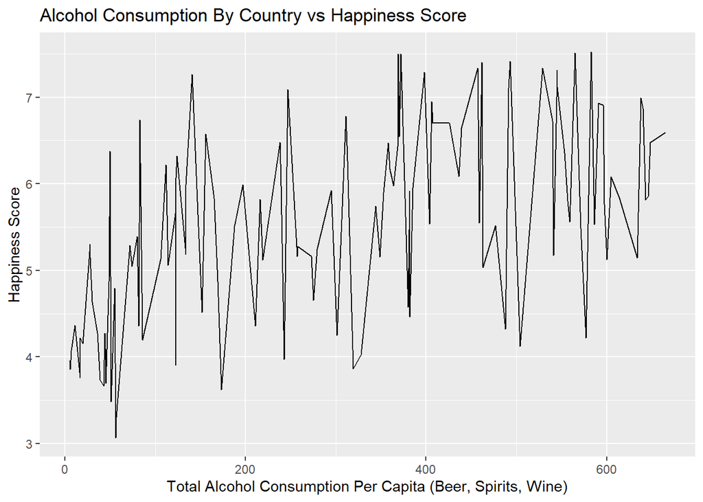

## Chart 2

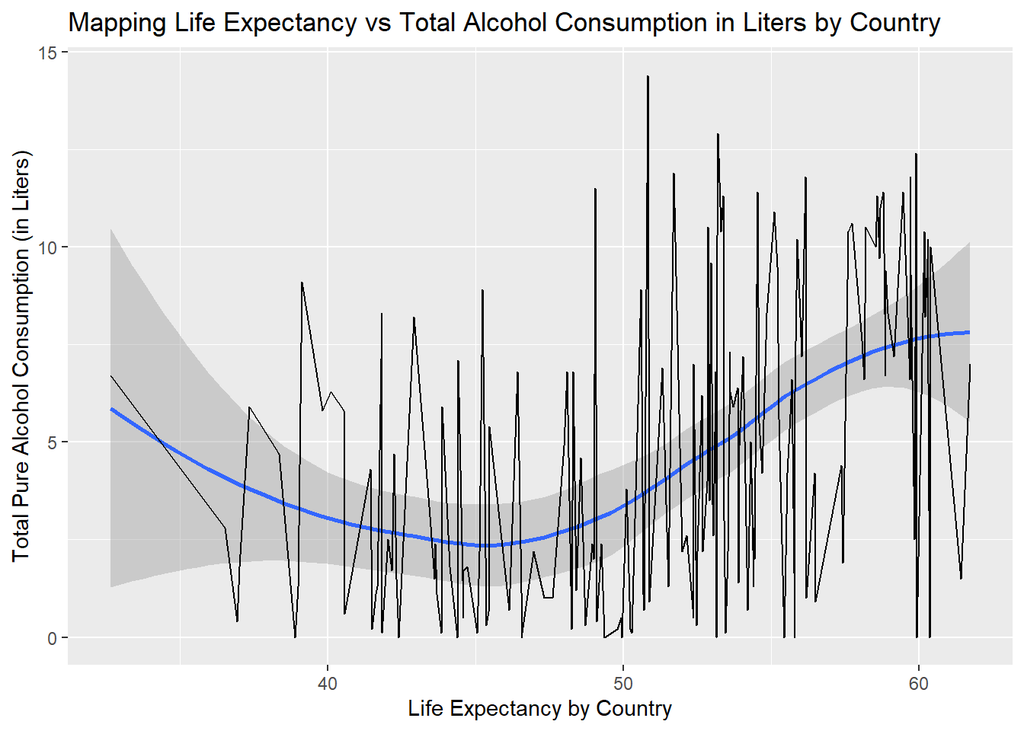

This chart once again shows, albeit inadvertently, a trend that we will come to hate. The fact that there are more factors than we can actually definitively study and draw a conclusion from that are affecting our perception of this chart. We can observe that the relationship between alcohol consumed and the life expectancy of countries is overall a **direct relationship**. However, there is something important to note here: countries with incredibly high level of alcohol consumption, in excess of **11** liters, are not those with the highest life expectancy.

## Chart 3

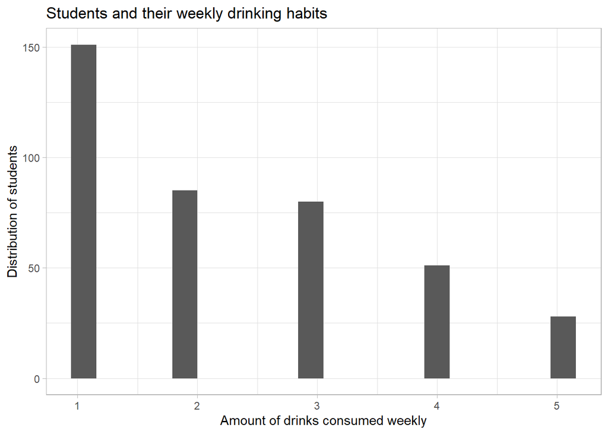

## Table

| Region | HappyScore | GDP |
| --- | --- | --- |
| Australia and New Zealand | 2 | 2 |
| Central and Eastern Europe | 27 | 9 |
| Eastern Asia | 4 | 2 |
| Latin America and Caribbean | 23 | 8 |
| Middle East and Northern Africa | 11 | 5 |
| North America | 2 | 2 |
| Southeastern Asia | 5 | 1 |
| Sub-Saharan Africa | 28 | 14 |
| Western Europe | 20 | 20 |

The table we included above relates variables and analyze patterns regarding how alcoholism affects happiness within various regions. We utilized the **groupby()** function to create a table that compares the total amount of **Happiness Scores**, as well as the total **GDP score** within certain regions. For this table, we only took Happy Scores between 3 and 8, as well as GDP scores between 10,000 and 100,000. This allowed us to ignore irrelevant values. The table showed us that there is a high GDP and Happiness Score within the Western Europe and Sub-Sahara African regions.